# 2022 - Data Analytics for Immersive Environments - CA4 - RDBMS & Linear Regression Project

CA4 Part B - Linear Regression Analysis

Joe O’Regan

2023-01-16

# Repo Link

https://github.com/joeaoregan/2022_DAIE_CA4_JOR1

# Statement of Assumptions

Variables to be tested should ideally be numeric for plotting graphs etc. Average monthly hours gaming (**avg_monthly_hrs_gaming**) would have a positive effect on average monthly expenditure downloadable content (DLC) (**avg_monthly_expenditure_dlc**).

The more hours a player plays games, the more inclined they would be to spend money on DLC. As the number of hours grows the expenditure should also grow.

I would assume there is linearity between the chosen variables and constant variance.

# Testing of Assumptions

Assumptions for Linear Regression

1. Independence of observation
2. Normality
3. Linearity
4. Homoscedasticity

**Independence of observation (No autocorrellation)**

No need to test for hidden relationships between variables when there is only one independent and one dependent variable. Find the R value or correlation between variables using cor().The variables age and avg_years_playing_games don’t have floating values so are more likely to repeat.

**Normality (Histograms, Shapiro-Wilk Significance Test**

Visually inspect normality with histograms. If the histogram is symmetrical/unimodal, then the data is assumed to be normally distributed.

Shapiro-Wilk Significance test. Visual inspection isn’t always reliable. Widely recommended for normality test and more powerful than Kolmogorov-Smirnov (K-S) nomality test.

Need to combine visual inspection and significance test to get good results, as normality test can be sensitive to sample size. Small samples can pass normality tests.

**Linearity**

Any relationship between the independent and dependent variable is linear: the line of best fit through the data points is a straight line and not a curve or grouping factor.

The statistical method for fitting a line to data where the relationship between two variables, x and y, can be modeled by a straight line with some error (M., D., D., C. and Çetinkaya-Rundel, M., 2019):

$Y = \beta0 + \beta1x + \epsilon$

**$\beta0$:** intercept, predicted value of y when x is 0  
**$\beta1$:** regression coefficient - how much y changes as x increases  
**$\epsilon$:** Error of estimate. How much variation exists in estimate of regression coefficient  
**x:** Explanatory variable (independent), influences y  
**y:** Response variable (dependent)

**Homoscedasticity**

Homogeneity of variance. The size of the error in our prediction doesn’t change significantly across the values of the independent variable.

Transforming the data had no impact with the p-value remaining low for all 3 transformations, log, square root and cube root.

# Analysis conducted and results obtained

**Correlation (R Value)**

Correlation between avg_monthly_hrs_gaming and avg_monthly_expenditure_dlc is smallest. There is no apparent linear relationship between the variables.

**Normality**

**Visual:** Inspecting the histograms, data is not normally distributed for both variables. For avg_monthly_hrs_gaming the histogram is skewed to the right. The histogram for avg_monthly_expenditure_dlc is roughly bell-shaped, but the number of breaks increases it appears multimodal.

**Significance:** Null hypothesis for Shapiro-Wilk’s normality test rejected for all variables before sampling. The p-value is less than 0.05 and the distribution of the data is significantly different from normal distribution.

**Linearity**

After checking data meets assumptions, check the relationship between independent and dependent variables using linear regression.

**Box plot:** Outliers in the prediction can negatively affect predictions as they may affect the direction/slope of the best fit line.

**Homoscedasticity**

Plot the linear model results to check whether the observed data meets our model assumptions.

Normal Q-Qplot doesn’t create a perfect one-to-one line with the theoretical residuals.

The red lines representing the mean of the residuals are not entirely horizontal.

**Plot**

**Line**

When the least squares line is added there is a very weak downward trend in the data.

**R and R squared**

Coefficient of determination (R2) tests how good the model is. The total variability explained by the regression model. Low r squared value means less variability is explained by the model.

High R squared isn’t necessary in every situation.

**Residuals**

Residuals appear to be still random when plotting the linear model residuals.

Data transformation might be an option.

**Boxplots**

No substantial outliers detected.

# R Code

## Load and Randomly Sample Data

```r
# Load and Randomly Sample Data
# use readr::read_csv() to load data from csv file

data <- read_csv("amalgamated_game_survey_250_2022.csv") # read data from csv
summary(data) # Check data has been read in correctly
```

```
##     gender               age        top_reason_gaming  gaming_platform
##  Length:250         Min.   :20.00   Length:250         Length:250
##  Class :character   1st Qu.:22.00   Class :character   Class :character
##  Mode  :character   Median :23.00   Mode  :character   Mode  :character
##                     Mean   :23.16
##                     3rd Qu.:24.00
##                     Max.   :33.00
##  favourite_game     avg_monthly_hrs_gaming avg_years_playing_games
##  Length:250         Min.   : 8.70          Min.   : 6.00
##  Class :character   1st Qu.:17.23          1st Qu.:10.00
##  Mode  :character   Median :19.80          Median :12.00
##                     Mean   :19.98          Mean   :11.78
##                     3rd Qu.:22.80          3rd Qu.:14.00
##                     Max.   :27.20          Max.   :17.00
##  avg_monthly_expenditure_dlc  ethnicity         play_roblox
##  Min.   :38.93               Length:250         Length:250
##  1st Qu.:47.47               Class :character   Class :character
##  Median :55.28               Mode  :character   Mode  :character
##  Mean   :55.48
##  3rd Qu.:63.48
##  Max.   :72.78
##   use_steam
##  Length:250
##  Class :character
##  Mode  :character
##
##
##
```

```r
# set a seed to reproduce random values
set.seed(1234)

# randomly sample 200 of the 250 rows
sample_data <- sample_n(data, 200) # returns tibble 200 x 11
```

## Calculate Linear Regression for Data

### 1. Independence of observation

Correlation / R Value

```r
# check the correlation between the chosen variables
cor(sample_data$avg_monthly_hrs_gaming, sample_data$avg_monthly_expenditure_dlc)
```

```
## [1] -0.01702819
```

```r
# perform correlation test on chosen variables
cor.test(sample_data$avg_monthly_hrs_gaming, sample_data$avg_monthly_expenditure_dlc)
```

```
##
##  Pearson's product-moment correlation
##
## data:  sample_data$avg_monthly_hrs_gaming and sample_data$avg_monthly_expenditure_dlc
## t = -0.23964, df = 198, p-value = 0.8109
## alternative hypothesis: true correlation is not equal to 0
## 95 percent confidence interval:
##  -0.1554021  0.1220011
## sample estimates:
##         cor
## -0.01702819
```

### 2. Normality

**Histograms**

Check data visually with histograms.

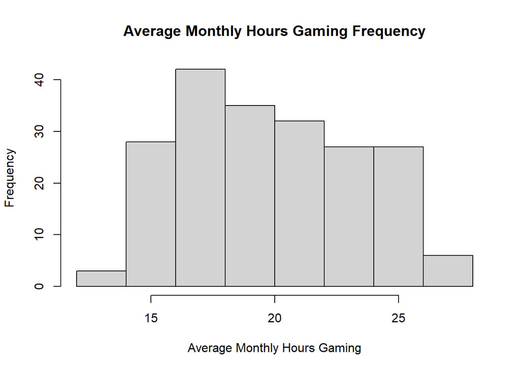

```r
hist(sample_data$avg_monthly_hrs_gaming,
     main="Average Monthly Hours Gaming Frequency",
     xlab="Average Monthly Hours Gaming")
```

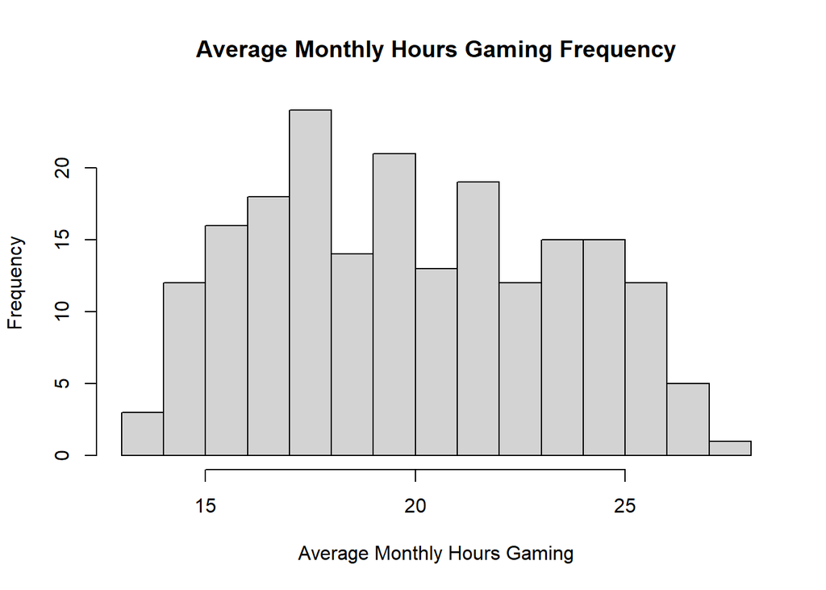

```r
hist(sample_data$avg_monthly_hrs_gaming,
     main="Average Monthly Hours Gaming Frequency",
     xlab="Average Monthly Hours Gaming",
     breaks=12)
```

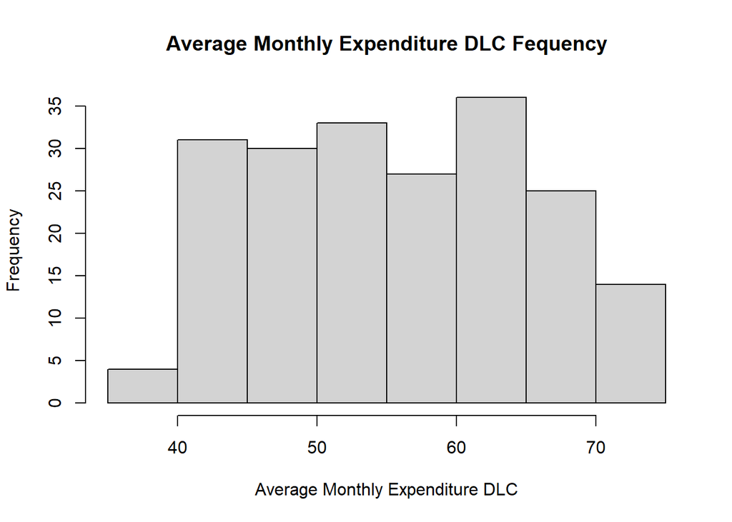

```r
hist(sample_data$avg_monthly_expenditure_dlc,
     main="Average Monthly Expenditure DLC Fequency",
     xlab = "Average Monthly Expenditure DLC")
```

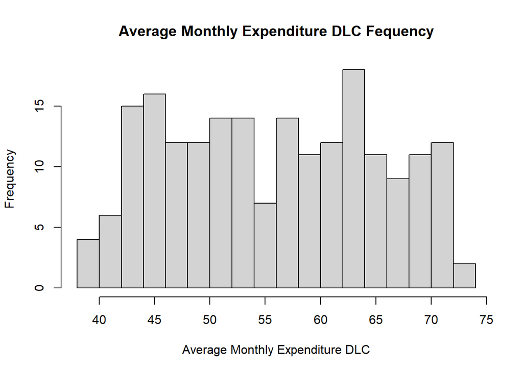

```r
hist(sample_data$avg_monthly_expenditure_dlc,
     main="Average Monthly Expenditure DLC Fequency",
     xlab = "Average Monthly Expenditure DLC",
     breaks=12)
```

Roughly bell-shaped. Increasing the breaks makes it appear multimodal.

**Shapiro-Wilk’s Method (Significance test)**

**null hypothesis:** the data are sampled from a Gaussian distribution.

```r
# Shapiro-Wilk's method for normality test

# If the P value is greater than 0.05 accept null hypothesis
# If the P value is less than or equal to 0.05 reject null hypothesis

significance <- 0.05

# perform shapiro test on avg_monthly_hrs_gaming
st_hours <- shapiro.test(sample_data$avg_monthly_hrs_gaming)

# if shapiro test result is too low reject the null hypothesis
if(st_hours$p.value < significance) {
  print("reject") } else {
  print("accept")
}
```

```
## [1] "reject"
```

```r
# perform shapiro test on avg_monthly_expenditure_dlc
st_bucks <- shapiro.test(sample_data$avg_monthly_expenditure_dlc)
# use ifelse() to perform similar check as above
print(ifelse(st_bucks$p.value < significance, "reject", "accept"))
```

```
## [1] "reject"
```

Null hypothesis rejected for all variables before sampling.

Data is not normally distributed for either variable.

### 3. Linear Regression Analysis

```r
# simple linear regression

# calculate effect of independent on dependent variable
mod <- lm(avg_monthly_expenditure_dlc ~ avg_monthly_hrs_gaming,
          data = sample_data)

# summarise the results of the model
summary(mod)
```

```
##
## Call:
## lm(formula = avg_monthly_expenditure_dlc ~ avg_monthly_hrs_gaming,
##     data = sample_data)
##
## Residuals:
##      Min       1Q   Median       3Q      Max
## -16.2939  -8.2364   0.2041   7.8369  17.2410
##
## Coefficients:
##                        Estimate Std. Error t value Pr(>|t|)
## (Intercept)            56.61685    3.83003   14.78   <2e-16 ***
## avg_monthly_hrs_gaming -0.04529    0.18899   -0.24    0.811
## ---
## Signif. codes:  0 '***' 0.001 '**' 0.01 '*' 0.05 '.' 0.1 ' ' 1
##
## Residual standard error: 9.321 on 198 degrees of freedom
## Multiple R-squared:  0.00029,    Adjusted R-squared:  -0.004759
## F-statistic: 0.05743 on 1 and 198 DF,  p-value: 0.8109
```

Not a Significant positive relationship between avg_monthly_hrs_gaming and avg_monthly_expenditure_dlc (p value > 0.05)

Equation for least-squares regression line: avg_monthly_expenditure_dlc = 56.61685 -0.04529*avg_monthly_hrs_gaming (When seed is set 1234 above set.seed(1234))

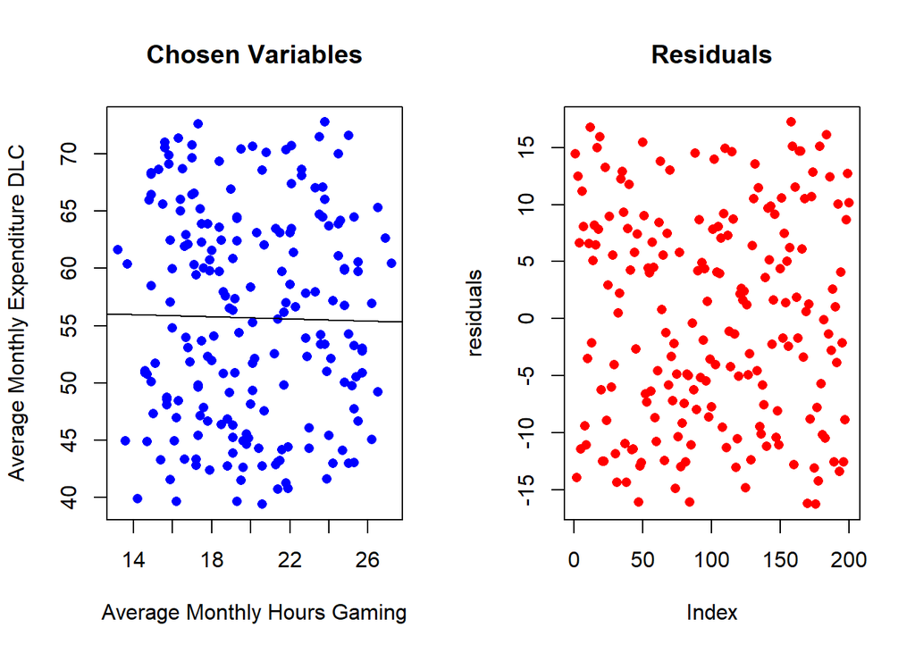

```r
#plot(sample_data$avg_monthly_hrs_gaming, mod$residuals)

df <- data.frame(sample_data$avg_monthly_hrs_gaming, sample_data$avg_monthly_expenditure_dlc)

par(mfrow=c(1,2), main="test") # 2 rows and 2 columns
plot(df, pch=16, col="blue",
     xlab="Average Monthly Hours Gaming",
     ylab="Average Monthly Expenditure DLC",
     main="Chosen Variables")
abline(mod)
plot(mod$residuals, pch=16, col="red", ylab="residuals", main="Residuals")
```

```r
par(mfrow=c(1,1)) # Reset to 1 row and 1 column
```

```r
# r squared value, percent of variation
r_squared <- summary(mod)$r.squared
r_squared
```

```
## [1] 0.0002899591
```

```r
# r value, derived from r squared
sqrt(r_squared)
```

```
## [1] 0.01702819
```

```r
# r value, using correlation function
cor(sample_data$avg_monthly_hrs_gaming, sample_data$avg_monthly_expenditure_dlc)
```

```
## [1] -0.01702819
```

Check for outliers

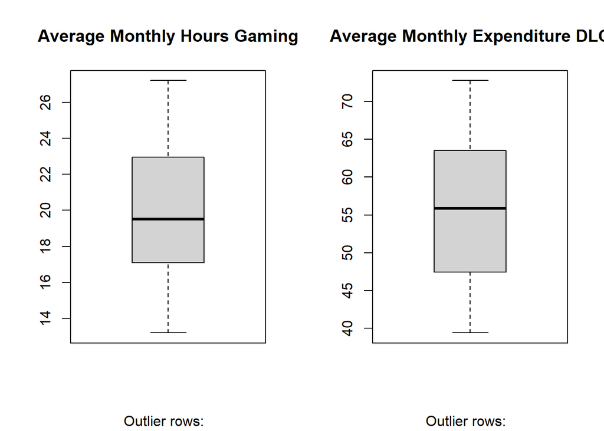

```r
par(mfrow=c(1, 2))  # divide graph area in 2 columns

boxplot(sample_data$avg_monthly_hrs_gaming,
        main="Average Monthly Hours Gaming",
        sub=paste("Outlier rows: ",
         boxplot.stats(sample_data$avg_monthly_hrs_gaming)$out))

boxplot(sample_data$avg_monthly_expenditure_dlc,
        main="Average Monthly Expenditure DLC",
        sub=paste("Outlier rows: ",
         boxplot.stats(sample_data$avg_monthly_expenditure_dlc)$out))
```

no outliers detected

### 4. Check for homoscedasticity

```r
par(mfrow=c(2,2), main="test") # 2 rows and 2 columns
```

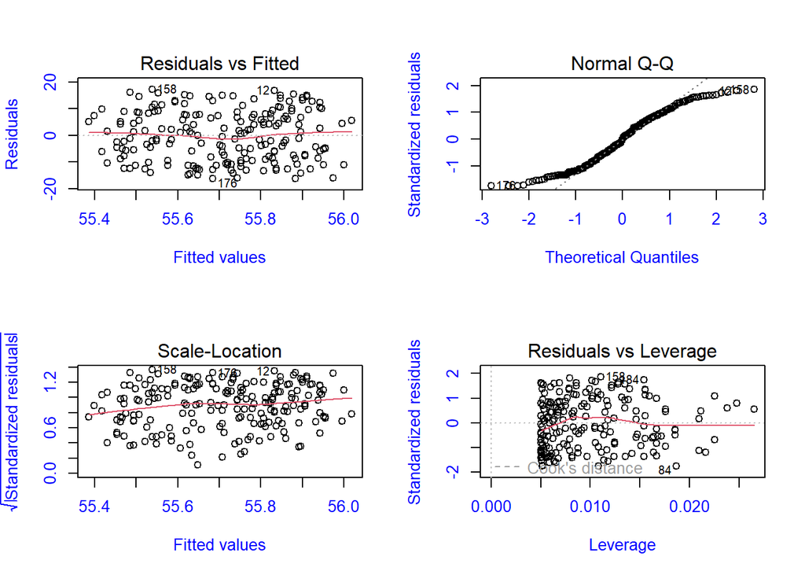

```r
plot(mod, col.lab="blue", col.axis="blue") # plot the model
```

```r
par(mfrow=c(1,1)) # Reset to 1 row and 1 column
```

Normal Q-Qplot doesn’t a perfect one-to-one line with the theoretical residuals.

## Linear Regression Plot(s)

The plot is created using the linear model data to map the avg_monthly_hrs_gaming and avg_montly_expenditure_dlc variables as points in the plot.

The scale of the x and y axiis are set using the rounded down min value for the variable and the max value rounded up. With just rounded values they were showing with a decimal place and didn’t look right.

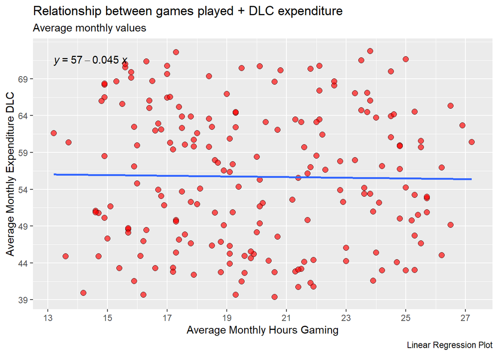

```r
# plot dataset in a scatter plot, add colours for points
plot <- ggplot(data = mod, mapping = aes(x = avg_monthly_hrs_gaming,
                                 y = avg_monthly_expenditure_dlc)) +
  geom_point(alpha = 0.66, # transparcency, lets stacked points show darker
             shape=21,# round
             fill="red", # inner colour
             color="black", # outline colour
             size=2.5) + # size (3 too big, 1 too small) +

  labs(title = "Relationship between games played + DLC expenditure",
       subtitle = "Average monthly values",
       caption = "Linear Regression Plot")

# Calculate x and y tick spacing and frequency
scale_x = scale_x_continuous(breaks = seq(
  floor(min(sample_data$avg_monthly_hrs_gaming)), # round down lowest value
  ceiling(max(sample_data$avg_monthly_hrs_gaming)), # round up highest value
  by = 2), # frequency
  name = "Average Monthly Hours Gaming") # x label
scale_y = scale_y_continuous(breaks = seq(
  floor(min(sample_data$avg_monthly_expenditure_dlc)),
  ceiling(max(sample_data$avg_monthly_expenditure_dlc)),
  by = 5),
  name = "Average Monthly Expenditure DLC")

# Get intercept and slope for regresion line
coeff <- coefficients(mod) # get coefficients returned from linear model
intercept <- coeff[1] # avg_monthly_hrs_gaming intercept
slope <- coeff[[2]] # slope of line, double square brackets = just the number

# Add x and y labels and geometry line to plot
plot + scale_x + scale_y +
  # geom_abline(intercept = intercept, slope = slope, color="red") + # regression line
  #stat_smooth(method = "lm", formula = y ~ x, geom = "smooth")
  geom_smooth(method="lm", se=F) +
  stat_regline_equation() # add equation to regression line
```

# Appendices

### Transform Data

Perform transformation: log, square root, or cube root. To see can data become more normally distributed.

```r
log_hours <- log10(sample_data$avg_monthly_hrs_gaming)
log_bucks <- log10(sample_data$avg_monthly_expenditure_dlc)

df_log <- data.frame(log_hours, log_bucks)
mod_log <- lm(log_bucks ~ log_hours, data=df_log)
summary(mod_log)
```

```
##
## Call:
## lm(formula = log_bucks ~ log_hours, data = df_log)
##
## Residuals:
##      Min       1Q   Median       3Q      Max
## -0.14413 -0.06323  0.00774  0.06338  0.12339
##
## Coefficients:
##             Estimate Std. Error t value Pr(>|t|)
## (Intercept)  1.75827    0.08854  19.859   <2e-16 ***
## log_hours   -0.01427    0.06833  -0.209    0.835
## ---
## Signif. codes:  0 '***' 0.001 '**' 0.01 '*' 0.05 '.' 0.1 ' ' 1
##
## Residual standard error: 0.07388 on 198 degrees of freedom
## Multiple R-squared:  0.0002204,  Adjusted R-squared:  -0.004829
## F-statistic: 0.04365 on 1 and 198 DF,  p-value: 0.8347
```

```r
sqrt_hours <- log10(sample_data$avg_monthly_hrs_gaming)
sqrt_bucks <- log10(sample_data$avg_monthly_expenditure_dlc)

df_sqrt <- data.frame(sqrt_hours, sqrt_bucks)
mod_sqrt <- lm(sqrt_bucks ~ sqrt_hours, data=df_sqrt)
summary(mod_sqrt)
```

```
##
## Call:
## lm(formula = sqrt_bucks ~ sqrt_hours, data = df_sqrt)
##
## Residuals:
##      Min       1Q   Median       3Q      Max
## -0.14413 -0.06323  0.00774  0.06338  0.12339
##
## Coefficients:
##             Estimate Std. Error t value Pr(>|t|)
## (Intercept)  1.75827    0.08854  19.859   <2e-16 ***
## sqrt_hours  -0.01427    0.06833  -0.209    0.835
## ---
## Signif. codes:  0 '***' 0.001 '**' 0.01 '*' 0.05 '.' 0.1 ' ' 1
##
## Residual standard error: 0.07388 on 198 degrees of freedom
## Multiple R-squared:  0.0002204,  Adjusted R-squared:  -0.004829
## F-statistic: 0.04365 on 1 and 198 DF,  p-value: 0.8347
```

```r
cube_hours <- sample_data$avg_monthly_hrs_gaming^(1/3)
cube_bucks <- sample_data$avg_monthly_expenditure_dlc^(1/3)

df_cube <- data.frame(cube_hours, cube_bucks)
mod_cube <- lm(cube_bucks ~ cube_hours, data=df_cube)
summary(mod_cube)
```

```
##
## Call:
## lm(formula = cube_bucks ~ cube_hours, data = df_cube)
##
## Residuals:
##      Min       1Q   Median       3Q      Max
## -0.40410 -0.18618  0.01661  0.18339  0.37140
##
## Coefficients:
##             Estimate Std. Error t value Pr(>|t|)
## (Intercept)  3.86404    0.25986  14.869   <2e-16 ***
## cube_hours  -0.02096    0.09596  -0.218    0.827
## ---
## Signif. codes:  0 '***' 0.001 '**' 0.01 '*' 0.05 '.' 0.1 ' ' 1
##
## Residual standard error: 0.2148 on 198 degrees of freedom
## Multiple R-squared:  0.000241,   Adjusted R-squared:  -0.004808
## F-statistic: 0.04772 on 1 and 198 DF,  p-value: 0.8273
```

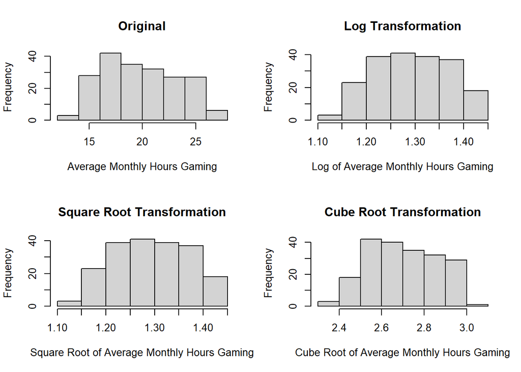

```r
par(mfrow=c(2,2)) # 2 rows and 2 columns

# avg_monthly_hrs_gaming transforms

hist(sample_data$avg_monthly_hrs_gaming, main='Original',
     xlab="Average Monthly Hours Gaming") # original
hist(log_hours, main='Log Transformation',
     xlab="Log of Average Monthly Hours Gaming") # log
hist(sqrt_hours, main='Square Root Transformation',
     xlab="Square Root of Average Monthly Hours Gaming") # square root
hist(cube_hours, main='Cube Root Transformation',
     xlab="Cube Root of Average Monthly Hours Gaming") # cube root
```

```r
par(mfrow=c(1,1)) # Reset to 1 row and 1 column
```

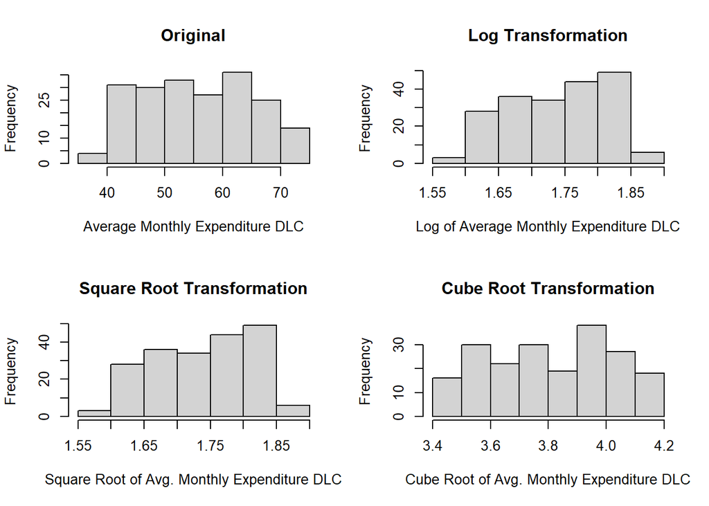

```r
par(mfrow=c(2,2)) # 2 rows and 2 columns

# avg_monthly_expenditure_dlc transforms

hist(sample_data$avg_monthly_expenditure_dlc, main='Original',
     xlab="Average Monthly Expenditure DLC") # original
hist(log_bucks, main='Log Transformation',
     xlab="Log of Average Monthly Expenditure DLC") # log
hist(sqrt_bucks, main='Square Root Transformation',
     xlab="Square Root of Avg. Monthly Expenditure DLC") # square root
hist(cube_bucks, main='Cube Root Transformation',
     xlab="Cube Root of Avg. Monthly Expenditure DLC") # cube root
```

```r
par(mfrow=c(1,1)) # Reset to 1 row and 1 column
```

```r
st1 <- shapiro.test(sample_data$avg_monthly_hrs_gaming)
st1
```

```
##
##  Shapiro-Wilk normality test
##
## data:  sample_data$avg_monthly_hrs_gaming
## W = 0.96331, p-value = 4.589e-05
```

```r
print(ifelse(st1$p.value < significance, "reject", "accept"))
```

```
## [1] "reject"
```

```r
st2 <- shapiro.test(log_hours)
print(ifelse(st2$p.value < significance, "reject", "accept"))
```

```
## [1] "reject"
```

```r
st3 <- shapiro.test(sqrt_hours)
print(ifelse(st3$p.value < significance, "reject", "accept"))
```

```
## [1] "reject"
```

```r
st4 <- shapiro.test(cube_hours)
print(ifelse(st4$p.value < significance, "reject", "accept"))
```

```
## [1] "reject"
```

```r
st5 <- shapiro.test(sample_data$avg_monthly_expenditure_dlc)
print(ifelse(st5$p.value < significance, "reject", "accept"))
```

```
## [1] "reject"
```

```r
st6 <- shapiro.test(log_bucks)
print(ifelse(st6$p.value < significance, "reject", "accept"))
```

```
## [1] "reject"
```

```r
st7 <- shapiro.test(sqrt_bucks)
print(ifelse(st7$p.value < significance, "reject", "accept"))
```

```
## [1] "reject"
```

```r
st8 <- shapiro.test(cube_bucks)
print(ifelse(st8$p.value < significance, "reject", "accept"))
```

```
## [1] "reject"
```

Well, that was a waste of time.

### Misc plots to try and make sense of the data (and failing)

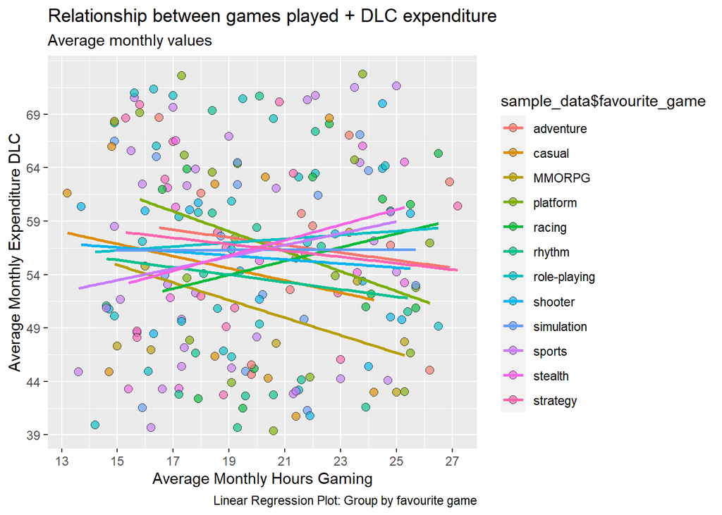

```r
plot <- ggplot(data = mod, mapping = aes(x = avg_monthly_hrs_gaming,
                                 y = avg_monthly_expenditure_dlc,
                                 fill=sample_data$favourite_game,
                                 color=sample_data$favourite_game)) +
  geom_point(alpha = 0.66, # transparcency, lets stacked points show darker
             shape=21,# round
             color="black", # outline colour
             size=2.5) + # size (3 too big, 1 too small) +

  labs(title = "Relationship between games played + DLC expenditure",
       subtitle = "Average monthly values",
       caption = "Linear Regression Plot: Group by favourite game")

# Add x and y labels and geometry line to plot
plot + scale_x + scale_y +
  geom_smooth(method="lm", se=F)
```

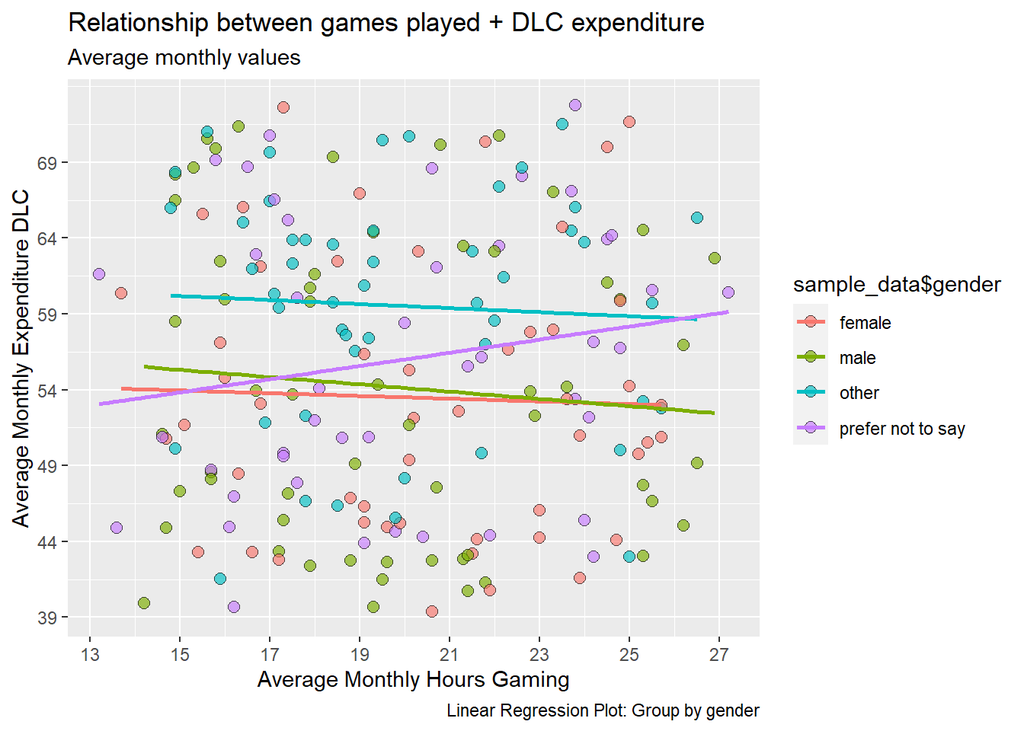

```r
plot <- ggplot(data = mod, mapping = aes(x = avg_monthly_hrs_gaming,
                                 y = avg_monthly_expenditure_dlc,
                                 fill=sample_data$gender,
                                 color=sample_data$gender)) +
  geom_point(alpha = 0.66, # transparcency, lets stacked points show darker
             shape=21,# round
             color="black", # outline colour
             size=2.5) + # size (3 too big, 1 too small) +

  labs(title = "Relationship between games played + DLC expenditure",
       subtitle = "Average monthly values",
       caption = "Linear Regression Plot: Group by gender")

# Add x and y labels and geometry line to plot
plot + scale_x + scale_y +
  geom_smooth(method="lm", se=F)
```

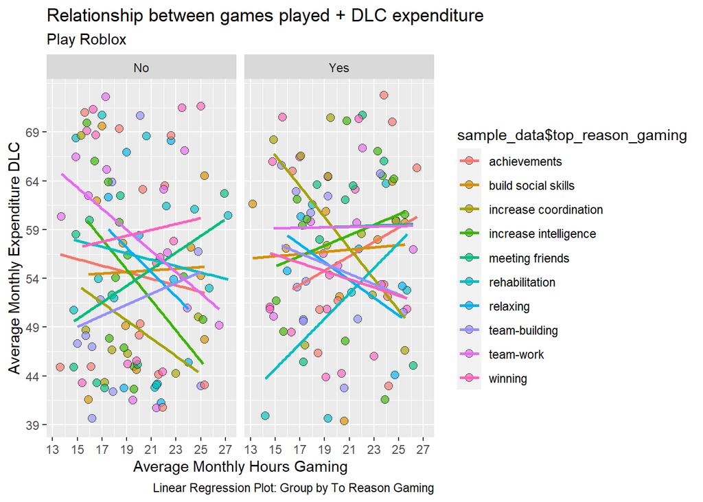

```r
plot <- ggplot(data = mod, mapping = aes(x = avg_monthly_hrs_gaming,
                                 y = avg_monthly_expenditure_dlc,
                                 fill=sample_data$top_reason_gaming,
                                 color=sample_data$top_reason_gaming)) +
  geom_point(alpha = 0.66, # transparcency, lets stacked points show darker
             shape=21,# round
             color="black", # outline colour
             size=2.5) + # size (3 too big, 1 too small) +

  labs(title = "Relationship between games played + DLC expenditure",
       subtitle = "Play Roblox",
       caption = "Linear Regression Plot: Group by To Reason Gaming")

# Add x and y labels and geometry line to plot
plot + scale_x + scale_y +
  geom_smooth(method="lm", se=F) +
  facet_grid(~sample_data$play_roblox)
```

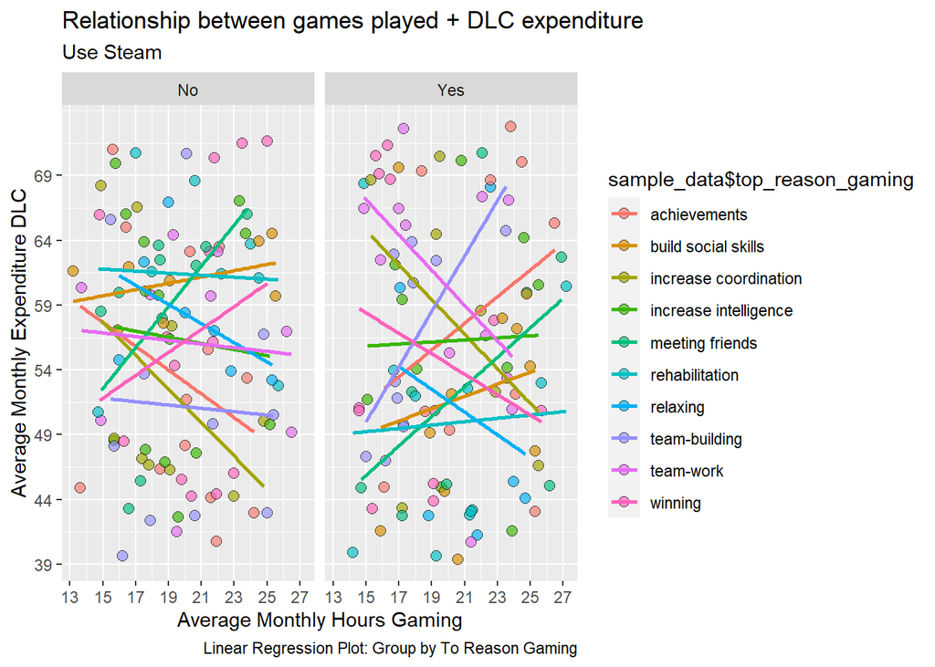

```r
plot <- ggplot(data = mod, mapping = aes(x = avg_monthly_hrs_gaming,
                                 y = avg_monthly_expenditure_dlc,
                                 fill=sample_data$top_reason_gaming,
                                 color=sample_data$top_reason_gaming)) +
  geom_point(alpha = 0.66, # transparcency, lets stacked points show darker
             shape=21,# round
             color="black", # outline colour
             size=2.5) + # size (3 too big, 1 too small) +

  labs(title = "Relationship between games played + DLC expenditure",
       subtitle = "Use Steam",
       caption = "Linear Regression Plot: Group by To Reason Gaming")

# Add x and y labels and geometry line to plot
plot + scale_x + scale_y +
  geom_smooth(method="lm", se=F) +
  facet_grid(~sample_data$use_steam)
```

# References

**OpenIntro Statistics:**

M., D., D., C. and Çetinkaya-Rundel, M., 2019. OpenIntro Statistics. OpenIntro, Incorporated.

OpenIntro Statistics. 2022. OpenIntro Statistics. [ONLINE] Available at: https://www.openintro.org/book/os/. [Accessed 18 January 2023].

**Linear Regression:**

Rebecca Bevans. 2023. Linear Regression in R | A Step-by-Step Guide & Examples. [ONLINE] Available at: https://www.scribbr.com/statistics/linear-regression-in-r/. [Accessed 18 January 2023].

Rebecca Bevans. 2023. Simple Linear Regression | An Easy Introduction & Examples. [ONLINE] Available at: https://www.scribbr.com/statistics/simple-linear-regression/. [Accessed 19 January 2023].

R Programming 101 (YouTube). 2023. Linear regression using R programming - YouTube. [ONLINE] Available at: https://www.youtube.com/watch?v=-mGXnm0fHtI. [Accessed 19 January 2023].

datacamp. 2023. Linear Regression in R Tutorial. [ONLINE] Available at: https://www.datacamp.com/tutorial/linear-regression-R. [Accessed 19 January 2023].

Linear Regression With R. 2023. Linear Regression With R. [ONLINE] Available at: http://r-statistics.co/Linear-Regression.html#Linear%20Regression%20Diagnostics. [Accessed 19 January 2023].

**GGPlot**

R Programming 101 (YouTube) 2023. ggplot for plots and graphs. An introduction to data visualization using R programming - YouTube. [ONLINE] Available at: https://www.youtube.com/watch?v=HPJn1CMvtmI. [Accessed 19 January 2023].

Data Carpentry contributors. 2023. Data visualization with ggplot2. [ONLINE] Available at: https://datacarpentry.org/R-ecology-lesson/04-visualization-ggplot2.html. [Accessed 19 January 2023].

ggplot2 point shapes - Easy Guides - Wiki - STHDA. 2023. ggplot2 point shapes - Easy Guides - Wiki - STHDA. [ONLINE] Available at: http://www.sthda.com/english/wiki/ggplot2-point-shapes. [Accessed 19 January 2023].

**Least-Squares Regression**

The Least-Square Regression Line and Equation. 2023. The Least-Square Regression Line and Equation. [ONLINE] Available at: https://rstudio-pubs-static.s3.amazonaws.com/199692_d02c8f7b352e4ec1b85544432ac28896.html. [Accessed 19 January 2023].

Linear Least Squares Regression — R Tutorial. 2023. 8. Linear Least Squares Regression — R Tutorial. [ONLINE] Available at: https://www.cyclismo.org/tutorial/R/linearLeastSquares.html. [Accessed 19 January 2023].

**Normality Tests**

Normality Test in R - Easy Guides - Wiki - STHDA. 2023. Normality Test in R - Easy Guides - Wiki - STHDA. [ONLINE] Available at: http://www.sthda.com/english/wiki/normality-test-in-r. [Accessed 19 January 2023].

Zach. 2023. How to Test for Normality in R (4 Methods) - Statology. [ONLINE] Available at: https://www.statology.org/test-for-normality-in-r/. [Accessed 19 January 2023].

**Transform Data**

Zach. 2023. How to Transform Data in R (Log, Square Root, Cube Root). [ONLINE] Available at: https://www.statology.org/transform-data-in-r/. [Accessed 19 January 2023].